# Credit Card Fraud Detection

```python
import pandas as pd
import matplotlib.pyplot as plt
import seaborn as sns

from sklearn.linear_model import LinearRegression, LogisticRegression
from sklearn.model_selection import train_test_split, GridSearchCV
from sklearn.tree import DecisionTreeClassifier
from sklearn.metrics import r2_score, classification_report, confusion_matrix, accuracy_score, roc_auc_score, roc_curve, precision_recall_curve, average_precision_score,precision_recall_fscore_support,balanced_accuracy_score, precision_score
from sklearn.neighbors import KNeighborsClassifier
from sklearn.ensemble import RandomForestClassifier

from time import time
import warnings
warnings.filterwarnings("ignore")
```

```python
df = pd.read_csv("/Users/navneetgujjar/Downloads/creditcard.csv")
df.head()
```

|  | Time | V1 | V2 | V3 | V4 | V5 | V6 | V7 | V8 | V9 | ... | V21 | V22 | V23 | V24 | V25 | V26 | V27 | V28 | Amount | Class |
| --- | --- | --- | --- | --- | --- | --- | --- | --- | --- | --- | --- | --- | --- | --- | --- | --- | --- | --- | --- | --- | --- |
| 0 | 0.0 | -1.359807 | -0.072781 | 2.536347 | 1.378155 | -0.338321 | 0.462388 | 0.239599 | 0.098698 | 0.363787 | ... | -0.018307 | 0.277838 | -0.110474 | 0.066928 | 0.128539 | -0.189115 | 0.133558 | -0.021053 | 149.62 | 0 |
| 1 | 0.0 | 1.191857 | 0.266151 | 0.166480 | 0.448154 | 0.060018 | -0.082361 | -0.078803 | 0.085102 | -0.255425 | ... | -0.225775 | -0.638672 | 0.101288 | -0.339846 | 0.167170 | 0.125895 | -0.008983 | 0.014724 | 2.69 | 0 |
| 2 | 1.0 | -1.358354 | -1.340163 | 1.773209 | 0.379780 | -0.503198 | 1.800499 | 0.791461 | 0.247676 | -1.514654 | ... | 0.247998 | 0.771679 | 0.909412 | -0.689281 | -0.327642 | -0.139097 | -0.055353 | -0.059752 | 378.66 | 0 |
| 3 | 1.0 | -0.966272 | -0.185226 | 1.792993 | -0.863291 | -0.010309 | 1.247203 | 0.237609 | 0.377436 | -1.387024 | ... | -0.108300 | 0.005274 | -0.190321 | -1.175575 | 0.647376 | -0.221929 | 0.062723 | 0.061458 | 123.50 | 0 |
| 4 | 2.0 | -1.158233 | 0.877737 | 1.548718 | 0.403034 | -0.407193 | 0.095921 | 0.592941 | -0.270533 | 0.817739 | ... | -0.009431 | 0.798278 | -0.137458 | 0.141267 | -0.206010 | 0.502292 | 0.219422 | 0.215153 | 69.99 | 0 |

5 rows × 31 columns

### The below resultset shows that there isn't any null value for any column in our dataset;

### If there are null values then it can impact the prediction.

### Null values can be removed or replaced with 0s, mean value of that particular column.

```python
df.isnull().sum()
```

```
Time      0
V1        0
V2        0
V3        0
V4        0
V5        0
V6        0
V7        0
V8        0
V9        0
V10       0
V11       0
V12       0
V13       0
V14       0
V15       0
V16       0
V17       0
V18       0
V19       0
V20       0
V21       0
V22       0
V23       0
V24       0
V25       0
V26       0
V27       0
V28       0
Amount    0
Class     0
dtype: int64
```

### Describing the numerical values i.e. 'Time', 'Class' and 'Amount'

```python
# describing Time and Class
df[['Time','Class']].describe()
```

|  | Time | Class |
| --- | --- | --- |
| count | 284807.000000 | 284807.000000 |
| mean | 94813.859575 | 0.001727 |
| std | 47488.145955 | 0.041527 |
| min | 0.000000 | 0.000000 |
| 25% | 54201.500000 | 0.000000 |
| 50% | 84692.000000 | 0.000000 |
| 75% | 139320.500000 | 0.000000 |
| max | 172792.000000 | 1.000000 |

```python
# describing AMOUNT COLUMN for fraud and genuine transactions
genuine_trans = df[df.Class==0]
fraud_trans = df[df.Class==1]

print("Amount stats for non fraud class: \n", genuine_trans.Amount.describe())
print("\nAmount stats for fraud class: \n", fraud_trans.Amount.describe())
```

```
Amount stats for non fraud class:
 count    284315.000000
mean         88.291022
std         250.105092
min           0.000000
25%           5.650000
50%          22.000000
75%          77.050000
max       25691.160000
Name: Amount, dtype: float64

Amount stats for fraud class:
 count     492.000000
mean      122.211321
std       256.683288
min         0.000000
25%         1.000000
50%         9.250000
75%       105.890000
max      2125.870000
Name: Amount, dtype: float64
```

### Conclusion: After describing the amount column it is concluded that it is fluctuating alot; therefore we need to scale it

### Scaling 'Amount' Column

```python
# Scaling amount column so as to check the amount corresponding to fraudulent transactions
from sklearn import preprocessing
scalar = preprocessing.StandardScaler()
cols = ['Amount']
# fit our data
scaled_cols = scalar.fit_transform(df[cols])
scaled_cols = pd.DataFrame(scaled_cols, columns=cols)
scaled_cols.head()
```

|  | Amount |
| --- | --- |
| 0 | 0.244964 |
| 1 | -0.342475 |
| 2 | 1.160686 |
| 3 | 0.140534 |
| 4 | -0.073403 |

```python
# number of genuine transactions
genuine_trans = len(df[df.Class == 0])
print('Number of Genuine Transactions ::',genuine_trans)
fraud_trans = len(df[df.Class == 1])
print('Number of Fraud Transactions ::', fraud_trans)
```

```
Number of Genuine Transactions :: 284315
Number of Fraud Transactions :: 492
```

### Checking correlation between Time, Class and Amount

```python
# selecting columns of interest
df_i = df.loc[:, ['Time', 'Class', 'Amount']]
df_i.head()
```

|  | Time | Class | Amount |
| --- | --- | --- | --- |
| 0 | 0.0 | 0 | 149.62 |
| 1 | 0.0 | 0 | 2.69 |
| 2 | 1.0 | 0 | 378.66 |
| 3 | 1.0 | 0 | 123.50 |
| 4 | 2.0 | 0 | 69.99 |

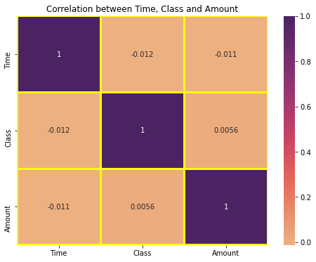

```python
plt.figure(figsize=(8,6))

sns.heatmap(df_i.corr(), annot = True, cmap = 'flare', linecolor = 'yellow', linewidth = 2)
plt.title('Correlation between Time, Class and Amount')
plt.show()
```

### Conclusion : There is a very less correlation betweeen Time, Class and Amount

### Plotting Count of Fraud and Genuine transactions

```
Class
0    284315
1       492
dtype: int64
```

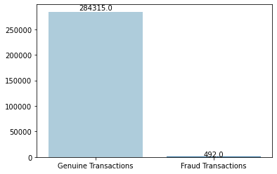

```python
import numpy as np
x_axis_labels = ['Genuine Transactions','Fraud Transactions']
count_class = df.value_counts(df['Class'])
print(count_class)

def show_values(axs, orient="v", space=1):
    def _single(ax):
        if orient == "v":
            for bar in ax.patches:
                _x = bar.get_x() + bar.get_width() / 2
                _y = bar.get_y() + bar.get_height() + (bar.get_height()*0.01)
                value = '{:.01f}'.format(bar.get_height())
                ax.text(_x, _y, value, ha="center")
        elif orient == "h":
            for bar in ax.patches:
                _x = bar.get_x() + bar.get_width() + float(space)
                _y = bar.get_y() + bar.get_height() - (bar.get_height()*0.5)
                value = '{:.01f}'.format(bar.get_width())
                ax.text(_x, _y, value, ha="left")

    if isinstance(axs, np.ndarray):
        for idx, ax in np.ndenumerate(axs):
            _single(ax)
    else:
        _single(axs)
bar = sns.barplot(y = count_class, x=x_axis_labels, data = count_class, palette ='Paired')
show_values(bar)
```

### Conclusion : Above bar chart shows that there are very less fraud transactions when compared to genuine transactions

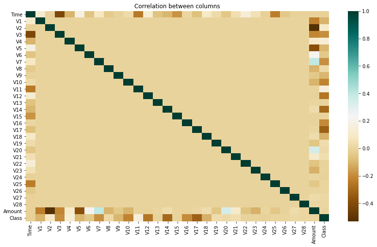

```python
plt.gcf().set_size_inches(14, 8)
sns.heatmap(df.corr(), annot=False, cmap='BrBG')
plt.title('Correlation between columns')
plt.show()
```

### Positive correlating features are V2, V4, V11, V19

### Negative correlating features: V10, V12, V14, V16

```
[Text(0.5, 1.0, 'Amount VS Time')]
```

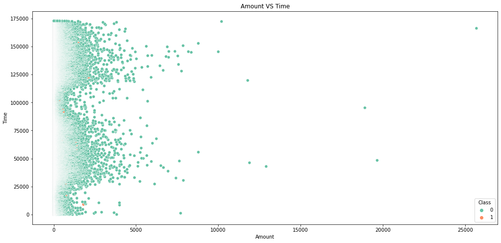

```python
#sns.relplot(data = df,x = "Amount", y = 'Class')
plt.gcf().set_size_inches(17, 8)

sns.scatterplot(data = df,x = "Amount", y = 'Time',hue = 'Class', palette = 'Set2', legend=True, sizes=(20, 200)).set(title='Amount VS Time')
```

```
[Text(0.5, 1.0, 'Amount VS Class')]
```

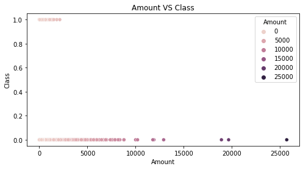

```python
plt.gcf().set_size_inches(8, 4)
sns.scatterplot(x="Amount", y="Class", hue = "Amount", data=df, sizes=(20, 200)).set(title = 'Amount VS Class')
```

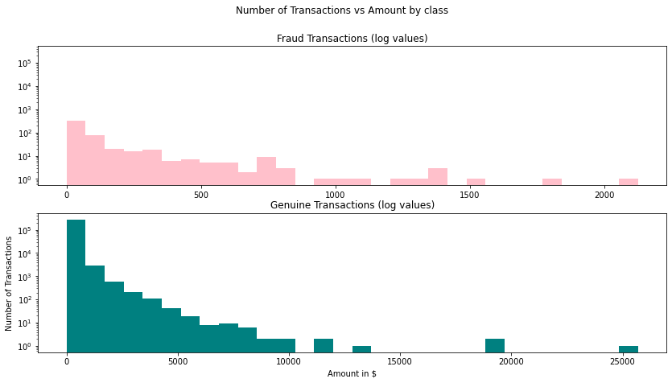

```python
f1, (ax1, ax2) = plt.subplots(2, 1,sharey=True, figsize=(14,7))
ax1.hist(df.Amount[df.Class == 1], color ='pink', bins = 30)
ax2.hist(df.Amount[df.Class == 0], color ='teal', bins = 30)

f1.suptitle('Number of Transactions vs Amount by class')
ax2.set_title('Genuine Transactions (log values)')
ax1.set_title('Fraud Transactions (log values)')

plt.xlabel('Amount in $')
plt.ylabel('Number of Transactions')
plt.yscale('log')
plt.show()
```

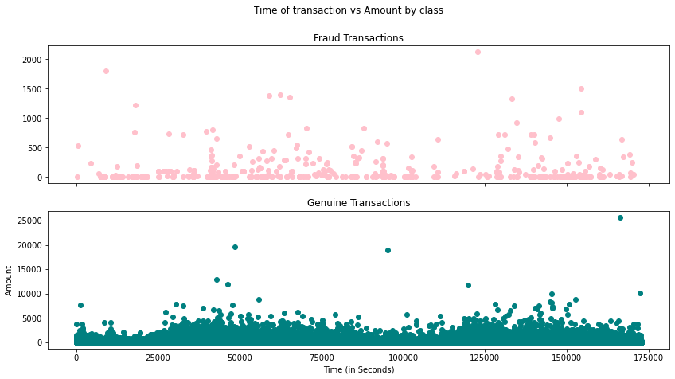

```python
frauds = df[df.Class == 1]
normal = df[df.Class == 0]
f, (ax3, ax4) = plt.subplots(2, 1, sharex=True, figsize=(14,7) )
f.suptitle('Time of transaction vs Amount by class')
ax3.scatter(frauds.Time, frauds.Amount, color ='pink')
ax3.set_title('Fraud Transactions')
ax4.scatter(normal.Time, normal.Amount, color ='teal')
ax4.set_title('Genuine Transactions')
plt.xlabel('Time (in Seconds)')
plt.ylabel('Amount')
plt.show()
```

### The above graph shows the Transaction Amount for Fraud and Genuine Transactions

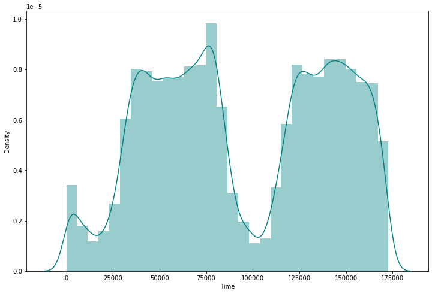

```python
plt.figure(figsize=(12,8))
b = sns.distplot(df['Time'], hist = True, kde = True, color ='teal', bins = 30)
plt.show()
```

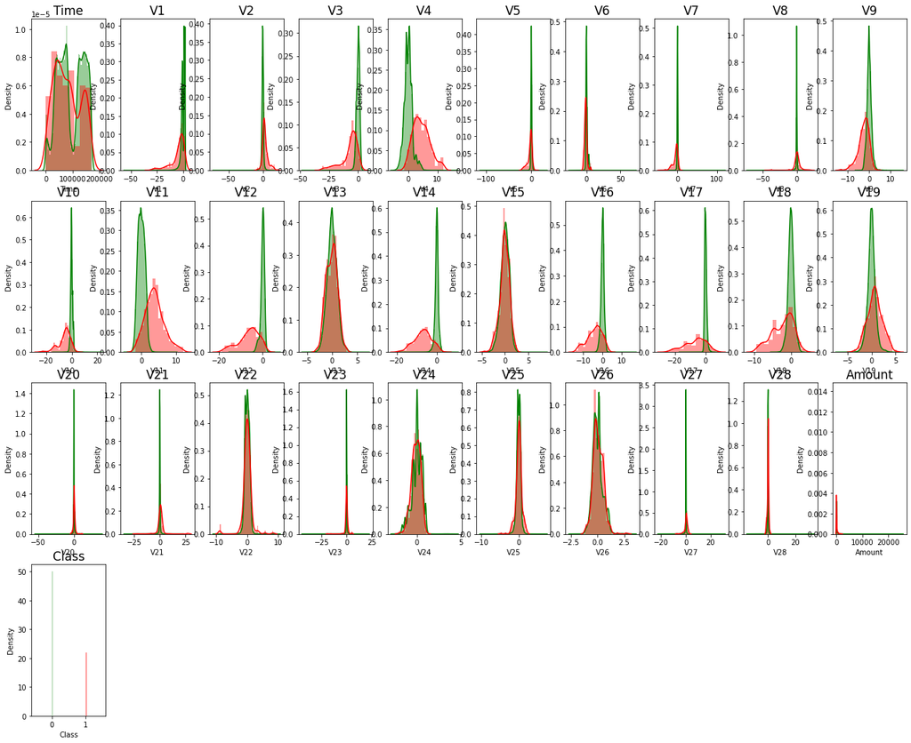

```python
cols = list(df.columns.values)

class_0 = df.Class == 0
class_1 = df.Class == 1

plt.figure(figsize=(22, 18))
for n, col in enumerate(cols):
    plt.subplot(4,10,n+1)
    sns.distplot(df[col][class_0], color='green')
    sns.distplot(df[col][class_1], color='red')
    plt.title(col, fontsize=17)
plt.show()
```

# SHAPE OF IMBALANCED DATA

```python
X = df.drop(["Class"],axis=1)
y = df["Class"]

X_train, X_test, y_train, y_test = train_test_split(X, y, test_size = 0.2, random_state = 2)
X = pd.concat([X_train, y_train] , axis = 1)
print('Shape of X (except Class) ::', X.shape)
print('Shape of y (class) ::',y.shape)
```

```
Shape of X (except Class) :: (227845, 31)
Shape of y (class) :: (284807,)
```

# [I] IMBALANCED DATA

```python
im_data = LogisticRegression()
im_data.fit(X_train, y_train)
im_data_ypred = im_data.predict(X_test)

print('Accuracy Score of Imbalanced Data by Logistic Regression:', accuracy_score(y_test,im_data_ypred))
print('Imbalanced Data Logistic Regression Report')
print(classification_report(y_test,im_data_ypred))
```

```
Accuracy Score of Imbalanced Data by Logistic Regression: 0.9989466661985184
Imbalanced Data Logistic Regression Report
              precision    recall  f1-score   support

           0       1.00      1.00      1.00     56878
           1       0.62      0.76      0.68        84

    accuracy                           1.00     56962
   macro avg       0.81      0.88      0.84     56962
weighted avg       1.00      1.00      1.00     56962
```

# [II] UPSAMPLING / OVERSAMPLING

```python
from sklearn.utils import resample

# X is the dataset that we got after split
genuine_trans1 = X[X.Class == 0]
fraud_trans1 = X[X.Class == 1]

fraud_upsampled_df = resample(fraud_trans1, replace=True, random_state=2, n_samples=len(genuine_trans1))
over_samp = pd.concat([genuine_trans1,fraud_upsampled_df])
over_samp.Class.value_counts()
```

```
0    227437
1    227437
Name: Class, dtype: int64
```

```python
over_samp.head()
```

|  | Time | V1 | V2 | V3 | V4 | V5 | V6 | V7 | V8 | V9 | ... | V21 | V22 | V23 | V24 | V25 | V26 | V27 | V28 | Amount | Class |
| --- | --- | --- | --- | --- | --- | --- | --- | --- | --- | --- | --- | --- | --- | --- | --- | --- | --- | --- | --- | --- | --- |
| 136700 | 81827.0 | -0.626902 | 1.172790 | 1.750623 | 0.868050 | 0.015424 | -0.771009 | 1.017371 | -0.533478 | -0.424700 | ... | 0.070241 | 0.369148 | -0.063796 | 0.734099 | -0.301282 | -0.502040 | -0.375145 | -0.081215 | 19.99 | 0 |
| 43219 | 41420.0 | -0.006068 | -2.885932 | -0.764538 | 0.091419 | -1.687394 | -0.859819 | 0.624534 | -0.416351 | -0.654780 | ... | 0.584560 | -0.003808 | -0.801507 | 0.453660 | 0.474506 | -0.140280 | -0.157441 | 0.130219 | 751.12 | 0 |
| 18819 | 29792.0 | -0.531514 | 0.611990 | 1.677510 | 1.281703 | 0.468128 | 0.025695 | 0.900121 | -0.306788 | 0.252843 | ... | -0.145452 | 0.238458 | -0.073162 | 0.066287 | -0.156348 | -0.283686 | -0.021930 | -0.245350 | 20.67 | 0 |
| 174557 | 121967.0 | 1.789550 | -0.556617 | -1.534874 | 0.343963 | 0.202157 | 0.118209 | -0.227615 | -0.003945 | 0.972636 | ... | -0.307981 | -1.132447 | 0.184282 | -0.424180 | -0.503949 | 0.134031 | -0.049449 | 0.006778 | 157.51 | 0 |
| 120641 | 75904.0 | 1.254183 | -0.106286 | -0.882852 | 0.308304 | 1.985428 | 3.808663 | -0.684194 | 0.938692 | 0.416300 | ... | -0.137631 | -0.289971 | -0.132417 | 1.018395 | 0.862443 | -0.282622 | 0.043088 | 0.015524 | 2.30 | 0 |

5 rows × 31 columns

```python
over_sampling_df = over_samp.copy()
over_sampling_df.head()
```

|  | Time | V1 | V2 | V3 | V4 | V5 | V6 | V7 | V8 | V9 | ... | V21 | V22 | V23 | V24 | V25 | V26 | V27 | V28 | Amount | Class |
| --- | --- | --- | --- | --- | --- | --- | --- | --- | --- | --- | --- | --- | --- | --- | --- | --- | --- | --- | --- | --- | --- |
| 136700 | 81827.0 | -0.626902 | 1.172790 | 1.750623 | 0.868050 | 0.015424 | -0.771009 | 1.017371 | -0.533478 | -0.424700 | ... | 0.070241 | 0.369148 | -0.063796 | 0.734099 | -0.301282 | -0.502040 | -0.375145 | -0.081215 | 19.99 | 0 |
| 43219 | 41420.0 | -0.006068 | -2.885932 | -0.764538 | 0.091419 | -1.687394 | -0.859819 | 0.624534 | -0.416351 | -0.654780 | ... | 0.584560 | -0.003808 | -0.801507 | 0.453660 | 0.474506 | -0.140280 | -0.157441 | 0.130219 | 751.12 | 0 |
| 18819 | 29792.0 | -0.531514 | 0.611990 | 1.677510 | 1.281703 | 0.468128 | 0.025695 | 0.900121 | -0.306788 | 0.252843 | ... | -0.145452 | 0.238458 | -0.073162 | 0.066287 | -0.156348 | -0.283686 | -0.021930 | -0.245350 | 20.67 | 0 |
| 174557 | 121967.0 | 1.789550 | -0.556617 | -1.534874 | 0.343963 | 0.202157 | 0.118209 | -0.227615 | -0.003945 | 0.972636 | ... | -0.307981 | -1.132447 | 0.184282 | -0.424180 | -0.503949 | 0.134031 | -0.049449 | 0.006778 | 157.51 | 0 |
| 120641 | 75904.0 | 1.254183 | -0.106286 | -0.882852 | 0.308304 | 1.985428 | 3.808663 | -0.684194 | 0.938692 | 0.416300 | ... | -0.137631 | -0.289971 | -0.132417 | 1.018395 | 0.862443 | -0.282622 | 0.043088 | 0.015524 | 2.30 | 0 |

5 rows × 31 columns

```python
# checking mean of the OVERSAMPLED DATA
over_samp.groupby('Class').mean()
# Conclusion : The mean of unbalanced data and OVersampled doesnt vary much, therefore the model is good.
```

| Class | Time | V1 | V2 | V3 | V4 | V5 | V6 | V7 | V8 | V9 | ... | V20 | V21 | V22 | V23 | V24 | V25 | V26 | V27 | V28 | Amount |
| --- | --- | --- | --- | --- | --- | --- | --- | --- | --- | --- | --- | --- | --- | --- | --- | --- | --- | --- | --- | --- | --- |
| 0 | 94797.526445 | 0.008743 | -0.003046 | 0.012771 | -0.010089 | 0.003853 | 0.000398 | 0.008129 | -0.001995 | 0.004284 | ... | -0.001176 | -0.001709 | -0.000183 | 0.000519 | -0.000827 | 0.000496 | -0.000442 | -0.000524 | -0.000372 | 87.873795 |
| 1 | 80338.345480 | -4.656838 | 3.504584 | -6.837202 | 4.390387 | -3.065630 | -1.327725 | -5.425878 | 0.410000 | -2.459714 | ... | 0.349240 | 0.665044 | 0.023748 | -0.061585 | -0.116955 | 0.023990 | 0.045587 | 0.167867 | 0.057667 | 128.951017 |

2 rows × 30 columns

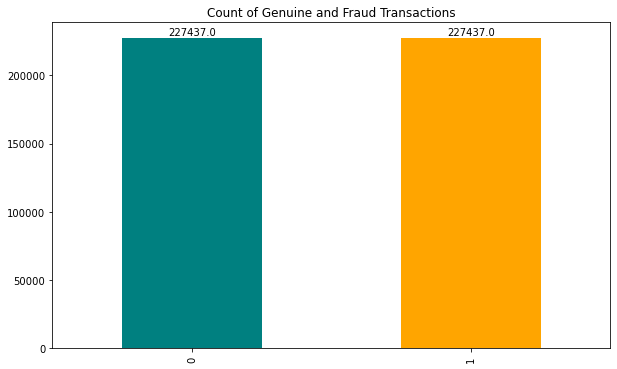

```python
plt.gcf().set_size_inches(10, 6)
# counting the values of Fraud and Genuine Transactions
plot1_count = over_samp['Class'].value_counts()


def show_values(axs, orient="v", space=1):
    def _single(ax):
        if orient == "v":
            for bar in ax.patches:
                _x = bar.get_x() + bar.get_width() / 2
                _y = bar.get_y() + bar.get_height() + (bar.get_height()*0.01)
                value = '{:.01f}'.format(bar.get_height())
                ax.text(_x, _y, value, ha="center")
        elif orient == "h":
            for bar in ax.patches:
                _x = bar.get_x() + bar.get_width() + float(space)
                _y = bar.get_y() + bar.get_height() - (bar.get_height()*0.5)
                value = '{:.01f}'.format(bar.get_width())
                ax.text(_x, _y, value, ha="left")

    if isinstance(axs, np.ndarray):
        for idx, ax in np.ndenumerate(axs):
            _single(ax)
    else:
        _single(axs)
# Plotting the bar chart

bar_plot2 = plot1_count.plot(kind='bar', title='Count of Genuine and Fraud Transactions', color=['teal', 'orange'])
show_values(bar_plot2)
```

### LOGISTIC REGRESSION OF OVERSAMPLED DATA

```python
y_train = over_samp.Class
X_train = over_samp.drop('Class',axis =1)

over_samp = LogisticRegression(solver='liblinear').fit(X_train, y_train)
over_samp_predict = over_samp.predict(X_test)

print('Accuracy Score by Logistic Regression for OVER SAMPLED DATA:', accuracy_score(y_test,over_samp_predict))
print('Logistic Regression Report for Over-Sampled Data')
print(classification_report(y_test,over_samp_predict))
```

```
Accuracy Score by Logistic Regression for OVER SAMPLED DATA: 0.973192654752291
Logistic Regression Report for Over-Sampled Data
              precision    recall  f1-score   support

           0       1.00      0.97      0.99     56878
           1       0.05      0.89      0.09        84

    accuracy                           0.97     56962
   macro avg       0.52      0.93      0.54     56962
weighted avg       1.00      0.97      0.99     56962
```

```
[Text(0.5, 1.0, 'Confusion Matrix after OVERSAMPLING')]
```

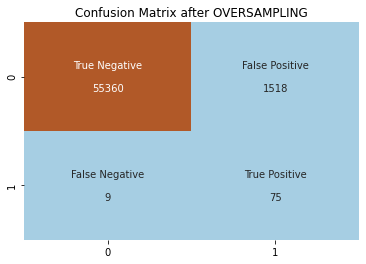

```python
# pd.DataFrame(confusion_matrix(y_test,over_samp_predict))
cf_matrix = confusion_matrix(y_test, over_samp_predict)
group_names = ['True Negative','False Positive','False Negative','True Positive']
group_counts = ['{0:0.0f}'.format(value) for value in cf_matrix.flatten()]

labels = [f'{v1}\n\n{v2}' for v1, v2 in zip(group_names,group_counts)]

labels = np.asarray(labels).reshape(2,2)

sns.heatmap(cf_matrix/np.sum(cf_matrix), annot=labels, fmt = '', cbar = False ,cmap = 'Paired').set(title  = 'Confusion Matrix after OVERSAMPLING')
```

# [III] UNDER SAMPLING

```python
# X is the dataset that we got after split
genuine_trans1 = X[X.Class == 0]
fraud_trans1 = X[X.Class == 1]

genuine_downsampled = resample(genuine_trans1, replace=True, random_state=42, n_samples=len(fraud_trans1))
down_samp = pd.concat([fraud_trans1,genuine_downsampled])
down_samp.Class.value_counts()
```

```
0    408
1    408
Name: Class, dtype: int64
```

### Plotting Undersampled Data

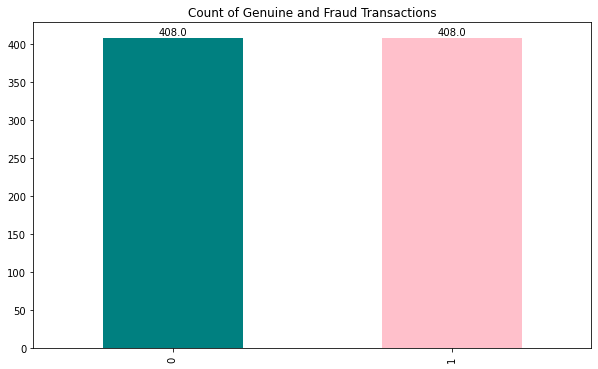

```python
plt.gcf().set_size_inches(10, 6)
# counting the values of Fraud and Genuine Transactions
plot1_count = down_samp['Class'].value_counts()


def show_values(axs, orient="v", space=1):
    def _single(ax):
        if orient == "v":
            for bar in ax.patches:
                _x = bar.get_x() + bar.get_width() / 2
                _y = bar.get_y() + bar.get_height() + (bar.get_height()*0.01)
                value = '{:.01f}'.format(bar.get_height())
                ax.text(_x, _y, value, ha="center")
        elif orient == "h":
            for bar in ax.patches:
                _x = bar.get_x() + bar.get_width() + float(space)
                _y = bar.get_y() + bar.get_height() - (bar.get_height()*0.5)
                value = '{:.01f}'.format(bar.get_width())
                ax.text(_x, _y, value, ha="left")

    if isinstance(axs, np.ndarray):
        for idx, ax in np.ndenumerate(axs):
            _single(ax)
    else:
        _single(axs)
# Plotting the bar chart
bar3 = plot1_count.plot(kind='bar', title='Count of Genuine and Fraud Transactions', color=['teal', 'pink'])
show_values(bar3)
```

```
<function matplotlib.pyplot.show(close=None, block=None)>
```

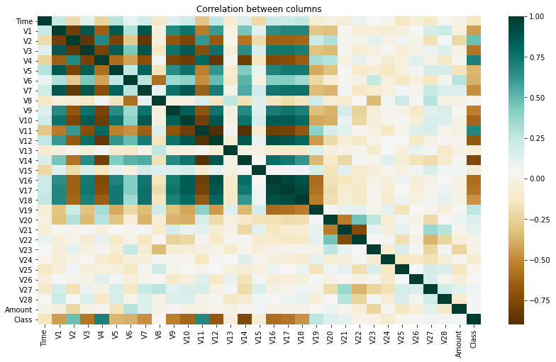

```python
plt.gcf().set_size_inches(14, 8)
sns.heatmap(down_samp.corr(), annot=False, cmap='BrBG')
plt.title('Correlation between columns')
plt.show
```

### LOGISTIC REGRESSION OF UNDERSAMPLED DATA

```python
# X is the dataset that we got after split
genuine_trans_0 = X[X.Class == 0]
fraud_trans_0 = X[X.Class == 1]

genuine_downsampled_df = resample(genuine_trans_0, replace=True, random_state=2, n_samples=len(fraud_trans_0))
down_sampl_df = pd.concat([fraud_trans_0,genuine_downsampled_df])
down_sampl_df.Class.value_counts()

start = time()

y_train = down_sampl_df.Class
X_train = down_sampl_df.drop('Class',axis =1)

down_sampl_df = LogisticRegression(solver='liblinear').fit(X_train, y_train)
down_sample_predict = down_sampl_df.predict(X_test)

print(f'Time taken to run Logistic Regression: {time() - start} seconds \n')

print('Accuracy Score by Logistic Regression:', accuracy_score(y_test,down_sample_predict))
print('Logistic Regression Report')
print(classification_report(y_test,down_sample_predict))
```

```
Time taken to run Logistic Regression: 0.007320880889892578 seconds

Accuracy Score by Logistic Regression: 0.9715950984867104
Logistic Regression Report
              precision    recall  f1-score   support

           0       1.00      0.97      0.99     56878
           1       0.04      0.88      0.08        84

    accuracy                           0.97     56962
   macro avg       0.52      0.93      0.53     56962
weighted avg       1.00      0.97      0.98     56962
```

```
[Text(0.5, 1.0, 'Confusion Matrix after Undersampled')]
```

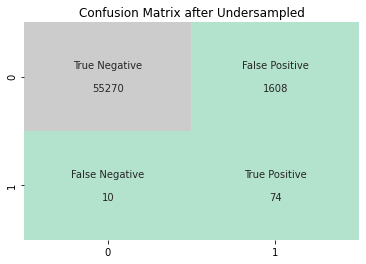

```python
#pd.DataFrame(confusion_matrix(y_test,down_sample_predict))
cf_matrix = confusion_matrix(y_test, down_sample_predict)
group_names_down = ['True Negative','False Positive','False Negative','True Positive']
group_counts_down = ['{0:0.0f}'.format(value) for value in cf_matrix.flatten()]

labels_down = [f'{v1}\n\n{v2}' for v1, v2 in zip(group_names_down,group_counts_down)]

labels_down = np.asarray(labels_down).reshape(2,2)

sns.heatmap(cf_matrix/np.sum(cf_matrix), annot=labels_down, fmt = '', cbar = False ,cmap = 'Pastel2').set(title  = 'Confusion Matrix after Undersampled')
```

# [IV] CLASS WEIGHTAGE FOR SAMPLING

```python
cnt_class_0 = y_train.value_counts()[0]
cnt_class_1 = y_train.value_counts()[1]

# ratio of the classes
ratio = cnt_class_0/cnt_class_1

LRCW = LogisticRegression(class_weight={1:ratio, 0:1})
LRCW.fit(X_train,y_train)
LRCW_pred = LRCW.predict(X_test)

print(classification_report(y_test,LRCW_pred))
print(accuracy_score(y_test, LRCW_pred))
```

```
              precision    recall  f1-score   support

           0       1.00      0.94      0.97     56878
           1       0.02      0.88      0.04        84

    accuracy                           0.94     56962
   macro avg       0.51      0.91      0.51     56962
weighted avg       1.00      0.94      0.97     56962

0.9436115304940136
```

```
[Text(0.5, 1.0, 'Confusion Matrix for Class Weight')]
```

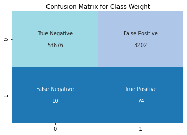

```python
# Confusion Matrix for Class Weight
cf_matrix = confusion_matrix(y_test, LRCW_pred)
group_names_cw = ['True Negative','False Positive','False Negative','True Positive']
group_counts_cw = ['{0:0.0f}'.format(value) for value in cf_matrix.flatten()]

labels_down = [f'{v1}\n\n{v2}' for v1, v2 in zip(group_names_cw,group_counts_cw)]

labels_down = np.asarray(labels_down).reshape(2,2)

sns.heatmap(cf_matrix/np.sum(cf_matrix), annot=labels_down, fmt = '', cbar = False ,cmap = 'tab20').set(title  = 'Confusion Matrix for Class Weight')
```

# PLOTTING DIMENSIONS FOR ALL THE SAMPLING TECHNIQUES

```python
# accuracy
accuracy_array = []
#accuracy_array.append(accuracy_score(y_test,im_data_ypred))
accuracy_array.append(accuracy_score(y_test,over_samp_predict))
accuracy_array.append(accuracy_score(y_test,down_sample_predict))
accuracy_array.append(accuracy_score(y_test,LRCW_pred))

# Recall , precision and f1 score support array
#rpf_im = precision_recall_fscore_support(y_test,im_data_ypred, average = 'macro')
rpf_over = precision_recall_fscore_support(y_test,over_samp_predict, average = 'macro')
rpf_under = precision_recall_fscore_support(y_test,down_sample_predict, average = 'macro')
rpf_cw = precision_recall_fscore_support(y_test,LRCW_pred, average = 'macro')

# precision
precision_all = [rpf_over[0],rpf_under[0],rpf_cw[0]]

# recall
recall_all = [rpf_over[1],rpf_under[1],rpf_cw[1]]

# f1- score
f1_score_all = [rpf_over[2],rpf_under[2],rpf_cw[2]]
```

```python
# Dataframe to store all the values
df_prf = pd.DataFrame()

df_prf['Sampling Techniques'] = [ 'Over-Sampling', 'Under-Sampling','Class Weight']
df_prf['Accuracy'] = accuracy_array
df_prf['Precision'] = precision_all
df_prf['Recall'] = recall_all
df_prf['F1_Score'] = f1_score_all
df_prf
```

|  | Sampling Techniques | Accuracy | Precision | Recall | F1_Score |
| --- | --- | --- | --- | --- | --- |
| 0 | Over-Sampling | 0.973193 | 0.523459 | 0.933084 | 0.537921 |
| 1 | Under-Sampling | 0.971595 | 0.521907 | 0.926341 | 0.534690 |
| 2 | Class Weight | 0.943612 | 0.511201 | 0.912328 | 0.507498 |

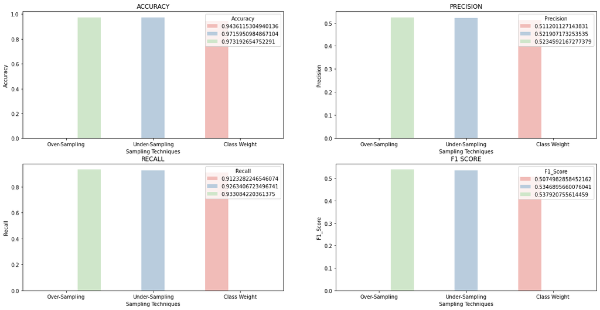

```python
f, axes = plt.subplots(2,2,figsize=(20,10))

sns.barplot(data=df_prf,x="Sampling Techniques", y="Accuracy", hue="Accuracy", palette="Pastel1",ax=axes[0,0]).set_title("ACCURACY")
sns.barplot(data=df_prf,x="Sampling Techniques", y="Precision", hue="Precision", palette="Pastel1", ax=axes[0,1]).set_title("PRECISION")
sns.barplot(data=df_prf,x="Sampling Techniques", y="Recall", hue="Recall", palette="Pastel1", ax=axes[1,0]).set_title("RECALL")
sns.barplot(data=df_prf,x="Sampling Techniques", y="F1_Score", hue="F1_Score", palette="Pastel1", ax=axes[1,1]).set_title("F1 SCORE")

plt.show()
```

## After using all three sampling techniques i.e. Oversampling, Under-Sampling and Class weight, we came to the conclusion that Over-sampling is the best technique to sample the data.

## This we have concluded from the Precision, Recall and F1_score rate.

# MODELS

### [I] LOGISTIC REGRESSION

```python
X_os = over_sampling_df.drop(["Class"],axis=1)
y_os = over_sampling_df["Class"]

X_train_os, X_test_os, y_train_os, y_test_os = train_test_split(X_os, y_os, test_size = 0.2, random_state = 2)
X_os = pd.concat([X_train_os, y_train_os] , axis = 1)
print('Shape of X (except Class) ::', X_os.shape)
print('Shape of y (class) ::',y_os.shape)

# y_train_os = over_samp.Class
# X_train = over_samp.drop('Class',axis =1)

over_samp_os = LogisticRegression(solver='liblinear').fit(X_train_os, y_train_os)
over_samp_predict_os = over_samp_os.predict(X_test_os)

print('Accuracy Score by Logistic Regression for OVER SAMPLED DATA:', accuracy_score(y_test_os,over_samp_predict_os))
print('Logistic Regression Report for Over-Sampled Data')
print(classification_report(y_test_os,over_samp_predict_os))
```

```
Shape of X (except Class) :: (363899, 31)
Shape of y (class) :: (454874,)
Accuracy Score by Logistic Regression for OVER SAMPLED DATA: 0.9401923605386096
Logistic Regression Report for Over-Sampled Data
              precision    recall  f1-score   support

           0       0.91      0.97      0.94     45382
           1       0.97      0.91      0.94     45593

    accuracy                           0.94     90975
   macro avg       0.94      0.94      0.94     90975
weighted avg       0.94      0.94      0.94     90975
```

### [II] DECISION TREE

```python
start = time()

tree_model_os = DecisionTreeClassifier(max_depth = 4, criterion = 'entropy').fit(X_train_os, y_train_os)
tree_model_predict_os = tree_model_os.predict(X_test_os)

print(f'Time taken to run Decision Tree Classifier: {time() - start} seconds \n')

print('Accuracy Score by Decision Tree Classifier for OVER SAMPLED DATA:', accuracy_score(y_test_os,tree_model_predict_os))
print('Decision Tree Classifier Report for Over-Sampled Data')
print(classification_report(y_test_os,tree_model_predict_os))
```

```
Time taken to run Decision Tree Classifier: 3.6957240104675293 seconds

Accuracy Score by Decision Tree Classifier for OVER SAMPLED DATA: 0.9432811211871394
Decision Tree Classifier Report for Over-Sampled Data
              precision    recall  f1-score   support

           0       0.90      0.99      0.95     45382
           1       0.99      0.89      0.94     45593

    accuracy                           0.94     90975
   macro avg       0.95      0.94      0.94     90975
weighted avg       0.95      0.94      0.94     90975
```

### [III] K-Nearest Neighbors

```python
start = time()
knn_os = KNeighborsClassifier(n_neighbors = 5, n_jobs=-1).fit(X_train_os, y_train_os)
knn_yhat_predict_os = knn_os.predict(X_test_os)
print(f'Time taken to run KNN Classifier: {time() - start} seconds')

print('Accuracy Score of KNN for OVER SAMPLED DATA:', accuracy_score(y_test_os,knn_yhat_predict_os))
print('KNN Report for OVER SAMPLED DATA \n')
print(classification_report(y_test_os,knn_yhat_predict_os))
```

```
Time taken to run KNN Classifier: 3.984949827194214 seconds
Accuracy Score of KNN for OVER SAMPLED DATA: 0.9990327012915636
KNN Report for OVER SAMPLED DATA

              precision    recall  f1-score   support

           0       1.00      1.00      1.00     45382
           1       1.00      1.00      1.00     45593

    accuracy                           1.00     90975
   macro avg       1.00      1.00      1.00     90975
weighted avg       1.00      1.00      1.00     90975
```

### [IV] RANDOM FOREST CLASSIFIER

```python
start = time()
RF_os = RandomForestClassifier(class_weight='balanced_subsample', random_state=5, n_estimators=100).fit(X_train_os, y_train_os)
RF_predict_os = RF_os.predict(X_test_os)
print(f'Time taken to run Random Forest Classifier: {time() - start} seconds')

print('Accuracy Score by Random Forest Classifier for OVER SAMPLED DATA :', accuracy_score(y_test_os,RF_predict_os))
print('RandomForest Classifier Report for OverSampled Data')
print(classification_report(y_test_os,RF_predict_os))
```

```
Time taken to run Random Forest Classifier: 88.48283314704895 seconds
Accuracy Score by Random Forest Classifier for OVER SAMPLED DATA : 0.9999560318768893
RandomForest Classifier Report for OverSampled Data
              precision    recall  f1-score   support

           0       1.00      1.00      1.00     45382
           1       1.00      1.00      1.00     45593

    accuracy                           1.00     90975
   macro avg       1.00      1.00      1.00     90975
weighted avg       1.00      1.00      1.00     90975
```

```python
accuracy_model = []
accuracy_model.append(accuracy_score(y_test_os,over_samp_predict_os))
accuracy_model.append(accuracy_score(y_test_os,tree_model_predict_os))
accuracy_model.append(accuracy_score(y_test_os,knn_yhat_predict_os))
accuracy_model.append(accuracy_score(y_test_os,RF_predict_os))

# Recall , precision and f1 score support array
rpf_lr = precision_recall_fscore_support(y_test_os,over_samp_predict_os, average = 'macro')
rpf_tm = precision_recall_fscore_support(y_test_os,tree_model_predict_os, average = 'macro')
rpf_knn = precision_recall_fscore_support(y_test_os,knn_yhat_predict_os, average = 'macro')
rpf_rf = precision_recall_fscore_support(y_test_os,RF_predict_os, average = 'macro')

precision_all_models = [rpf_lr[0],rpf_tm[0],rpf_knn[0],rpf_rf[0]]
recall_all_models = [rpf_lr[1],rpf_tm[1],rpf_knn[1],rpf_rf[1]]
f1_score_all_models = [rpf_lr[2],rpf_tm[2],rpf_knn[2],rpf_rf[2]]

df_models = pd.DataFrame()

df_models['Models'] = [ 'Logistic Regression', 'Decision Tree Classifier','KNN Classfier', 'Random Forest Classifier']
df_models['Accuracy'] = accuracy_model
df_models['Precision'] = precision_all_models
df_models['Recall'] = recall_all_models
df_models['F1_Score'] = f1_score_all_models
df_models
```

|  | Models | Accuracy | Precision | Recall | F1_Score |
| --- | --- | --- | --- | --- | --- |
| 0 | Logistic Regression | 0.940192 | 0.942126 | 0.940270 | 0.940134 |
| 1 | Decision Tree Classifier | 0.943281 | 0.947432 | 0.943394 | 0.943159 |
| 2 | KNN Classfier | 0.999033 | 0.999037 | 0.999030 | 0.999033 |
| 3 | Random Forest Classifier | 0.999956 | 0.999956 | 0.999956 | 0.999956 |

## ROC

### True Positive Rate and False Positive Rate are required to built ROC Curve.

```python
lr_pred_test_prob = over_samp_os.predict_proba(X_test_os)[:, 1]
```

```python
fpr, tpr, threshold = roc_curve(y_test_os, lr_pred_test_prob)
```

```python
lr_auc = roc_auc_score(y_test_os, lr_pred_test_prob)
lr_auc
```

```
0.9762162584186312
```

```python
def plot_roc_curve(fpr, tpr, label=None):
    plt.figure(figsize=(8, 6))
    plt.title('ROC Curve', fontsize=15)
    plt.plot([0, 1], [0, 1], 'k--')
    plt.plot(fpr, tpr, linewidth=2, label=label)
    plt.xticks(np.arange(0, 1, 0.05), rotation=90)
    plt.xlabel('False Positive Rates', fontsize=15)
    plt.ylabel('True Positive Rates', fontsize=15)
    plt.legend(loc='best')

    plt.show()
```

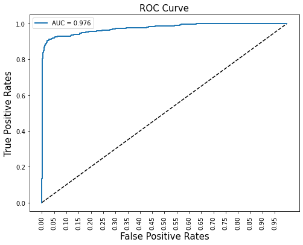

```python
plot_roc_curve(fpr=fpr, tpr=tpr, label="AUC = %.3f" % lr_auc)
```